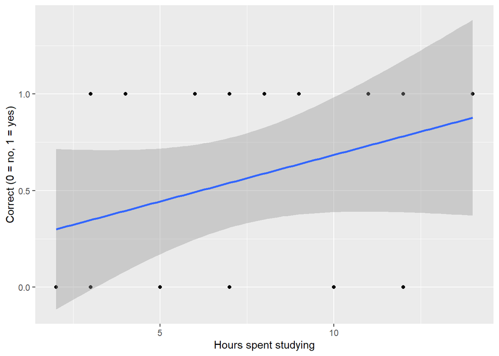

An attempt to fit a linear regression model to a binary response variable.

```r
# Packages required for Chapter 2
library(gridExtra)
library(knitr)
library(mosaic)
library(xtable)
library(kableExtra)
library(tidyverse)
```

## Exercises

### Question 1

1. Suppose we plan to use data to estimate one parameter, $p_B$.
   - When using a likelihood to obtain an estimate for the parameter, which is preferred: a large or a small likelihood value? Why?  
     A large likelihood value is preferred when estimating a parameter, because it means that the observed data is more probable under the assumed model and parameter value

### Question 2

2. Suppose the families with an “only child” were excluded for the Sex Conditional Model. How might the estimates for the three parameters be affected? Would it still be possible to perform a Likelihood Ratio Test to compare the Sex Unconditional and Sex Conditional Models? Why or why not?  
   For conditional singleton families greatly help estimate Pb|N. Removing singleton families would not affect Pb|b_{bias} Pb|g_{bias} though. For unconditional models it would make the sample size smaller worsening the parameter estimate. It would still be possbile to run a Likelihood Ratio Test if both models had no singleton families as the Likelihood Ratio Test compares the likelihoods of the two models for the same data.

### Question 3

1. Write out the likelihood for a model which assumes the probability of a girl equals the probability of a boy. Carry out a LRT to determine whether there is evidence that the two probabilities are not equal. Comment on the practical significance of this finding (there is not necessarily one correct answer).

```r
# Apply Model 1 to NLSY data (for families with 3 or fewer
# children)
# possible values for prob a boy is born
pb <- seq(0, 1, length = 10001)
# loglik of getting obs data
loglik <- 5416 * log(pb) + 5256 * log(1 - pb)
# maximum loglikelihood over all values of pb
max(loglik)
```

```
## [1] -7396.067
```

```r
# MLE of pb
pb[loglik==max(loglik)]
```

```
## [1] 0.5075
```

```r
max_logL_m1_nlsy <- max(loglik)
# Model 0 is Model 1 with pb set equal to 0.5
maxloglik0 <- 5416 * log(0.5) + 5256 * log(1 - 0.5)
maxloglik0
```

```
## [1] -7397.267
```

```r
# lrt
lrt <- 2 * (max_logL_m1_nlsy - maxloglik0)
lrt
```

```
## [1] 2.39889
```

```r
# Find P val
pval <- 1 - pchisq(lrt, df = 1)
pval
```

```
## [1] 0.1214214
```

Since p value is greater than .05 we do not reject the null hypothesis that the probability of a not is the same as the probabilty of a girl.